# Tips to increase a profit

Dana Yerlanova

2019/04/05

## By the way, I started to work with dataset where we should provide a tips to increase the profit of company.This dataset contains information of 2016-2018 sales. Our mission is to find what kind of factors affect to the profit and what company should do to acclerate its disposal.

### 3.1 Loading libraries required and reading the data into R

[figure not shown]

### Mutate new column profit, which equals Fact..KZT..with.discount.- Cost.of.sales

```
## [1] 809  19
```

```
## 'data.frame':    809 obs. of  11 variables:
##  $ Date                        : Date, format: "2016-01-01" "2016-01-02" ...
##  $ Plan..KZT                   : num  1711959 2853264 2282606 1141306 1141306 ...
##  $ Fact..KZT..with.discount.   : int  662900 2275290 1782140 1961640 1131760 1327130 1221810 1001260 2048270 1564250 ...
##  $ Fact..KZT..without.discount.: int  1252950 3660850 2976800 3334000 1819850 2103700 2127800 1621000 3356550 2767650 ...
##  $ Diff..KZT                   : int  -1049059 -577974 -500466 820334 -9546 185824 80504 -710699 -804994 -718356 ...
##  $ Average.discount            : num  47.1 37.9 40.1 41.2 37.8 ...
##  $ Traffic                     : int  638 1507 1179 1191 622 689 1000 666 1022 910 ...
##  $ Receipt..customers.         : int  41 103 85 96 51 49 75 48 71 64 ...
##  $ Sold.pcs                    : int  61 163 124 140 83 86 104 80 149 127 ...
##  $ pcs..customers              : num  1.49 1.58 1.46 1.46 1.63 1.76 1.39 1.67 2.1 1.98 ...
##  $ weekday                     : chr  "пятница" "суббота" "воскресенье" "понедельник" ...
```

```
##                         Date                    Plan..KZT
##                            0                            0
##    Fact..KZT..with.discount. Fact..KZT..without.discount.
##                            0                            0
##                    Diff..KZT             Average.discount
##                            0                            0
##                      Traffic          Receipt..customers.
##                            0                            0
##                     Sold.pcs               pcs..customers
##                            0                            0
##     Averame.amount.of.cheque          Average.price.piece
##                            0                            0
##                 Qty.of.hours                 Productivity
##                            0                            0
##                Cost.of.sales                         year
##                            1                            0
##                        month                          day
##                            0                            0
##                      weekday
##                            0
```

### 1.Plans of shop, and real profit in 2016, 2017, 2018

```r
df_year <- df%>% group_by(year)%>%summarize(meanProfit=mean(Profit), total=sum(Profit), planProfit= sum(Plan..KZT), difference = planProfit-total)
datatable(df_year)
```

|  | year | meanProfit | total | planProfit | difference |
| --- | --- | --- | --- | --- | --- |
| 1 | 2016 | 861028.232240437 | 315136333 | 596349013 | 281212680 |
| 2 | 2017 | 777620.224550898 | 259725155 | 512424433 | 252699278 |
| 3 | 2018 |  |  | 176904880 |  |

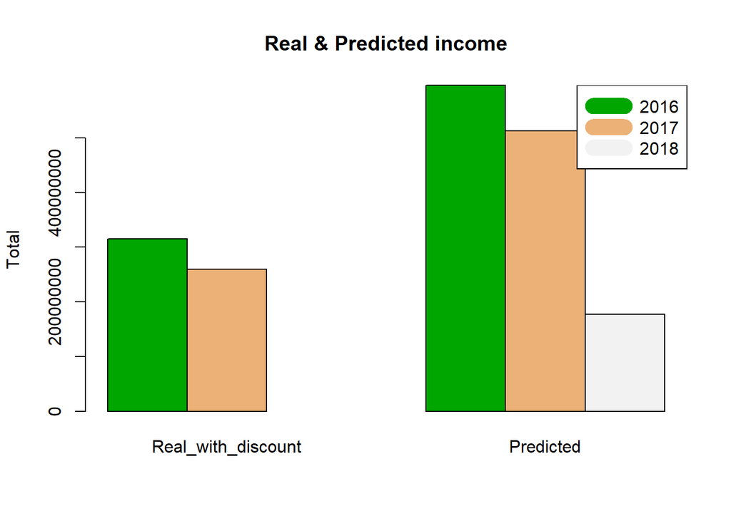

```r
options(scipen=100000)
mydata <- data.frame(Real_with_discount=df_year$total, Predicted=df_year$planProfit)
barplot(as.matrix(mydata), main="Real & Predicted income", ylab="Total", beside=TRUE,
        col=terrain.colors(3))
legend("topright", c("2016", "2017","2018"), col=terrain.colors(3), lwd=15);
```

## 2. Traffic

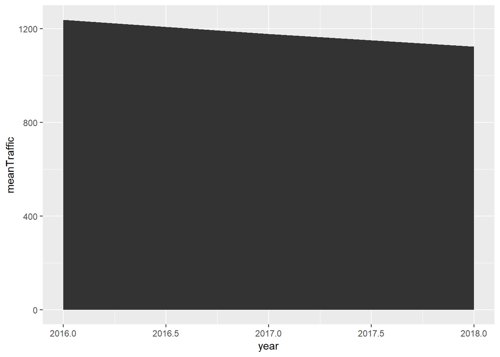

```r
df1<-df%>%group_by(year)%>%summarize(meanTraffic=mean(Traffic))
ggplot(data=df1, aes(year, meanTraffic))+
  geom_area()
```

# SEASON

## 1.Let’s check factor month, weekday. Maybe, having low income due to seasonality?

```r
df_sale_month <- df%>%group_by(month)%>%summarize(meanProfitMonth = mean(Profit),meanTrafficM = mean(Traffic),meanCustomerM = mean(Receipt..customers.))
df_sale_month
```

```
## # A tibble: 12 x 4
##    month meanProfitMonth meanTrafficM meanCustomerM
##    <dbl>           <dbl>        <dbl>         <dbl>
##  1     1         570195.        1110.          77.2
##  2     2         392702.        1082.          88.1
##  3     3         688454.         902.          46.9
##  4     4             NA          811.          45.3
##  5     5         820478.         902.          54.2
##  6     6         878132.        1258.          63.2
##  7     7         794000.        1696.          88.3
##  8     8         896031.        2470.         118.
##  9     9         964916.        1187           56.1
## 10    10        1176003.        1321.          54.6
## 11    11         893262.        1217.          46.5
## 12    12         890199.        1404.          70.0
```

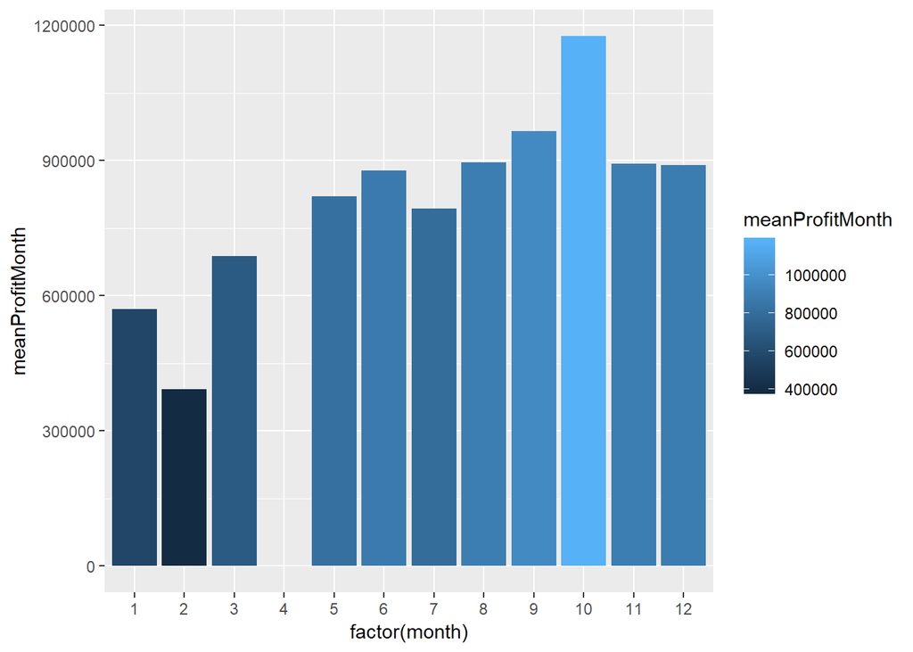

```r
ggplot(data=df_sale_month, aes(factor(month), meanProfitMonth, fill=meanProfitMonth))+
  geom_bar(stat="identity")
```

###As a result, the most high selling month is October, the lowest is February

## So, let’s try to look at profit for every season:

```r
df_sale_season <- df%>%mutate(Season = ifelse(month<=2|month==12, 'Winter', ifelse(month>=3&month<=5, 'Spring',ifelse(month>=6&month<=8, 'Summer','Fall'))))
df_season <- df_sale_season%>%group_by(Season)%>%summarize(meanP = mean(Profit),meanTr = mean(Traffic))
df_season
```

```
## # A tibble: 4 x 3
##   Season    meanP meanTr
##   <chr>     <dbl>  <dbl>
## 1 Fall   1013203.  1242.
## 2 Spring      NA    871.
## 3 Summer  847666.  1681.
## 4 Winter  589261.  1175.
```

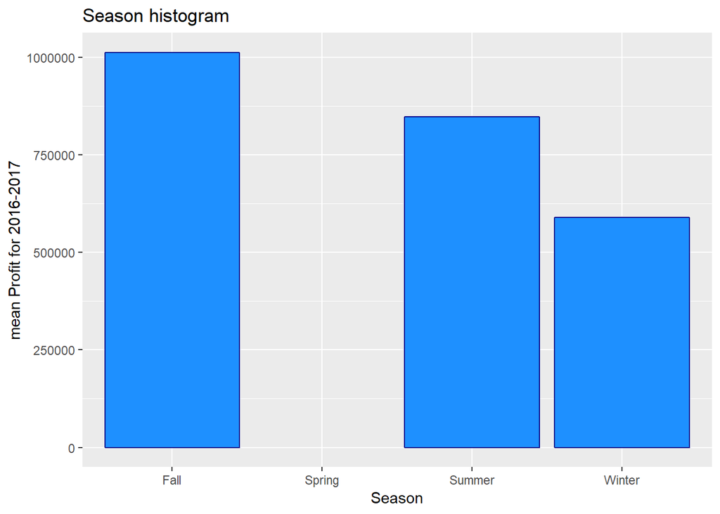

```r
library(ggplot2)
ggplot(data=df_season, aes(Season,meanP))+
 geom_bar(stat="identity",fill = '#1E90FF', color ='#00008B')+
  ggtitle('Season histogram') +
  ylab('mean Profit for 2016-2017') +
  xlab('Season')
```

## 2. So, now let’s check, how weekday affect to this measurements

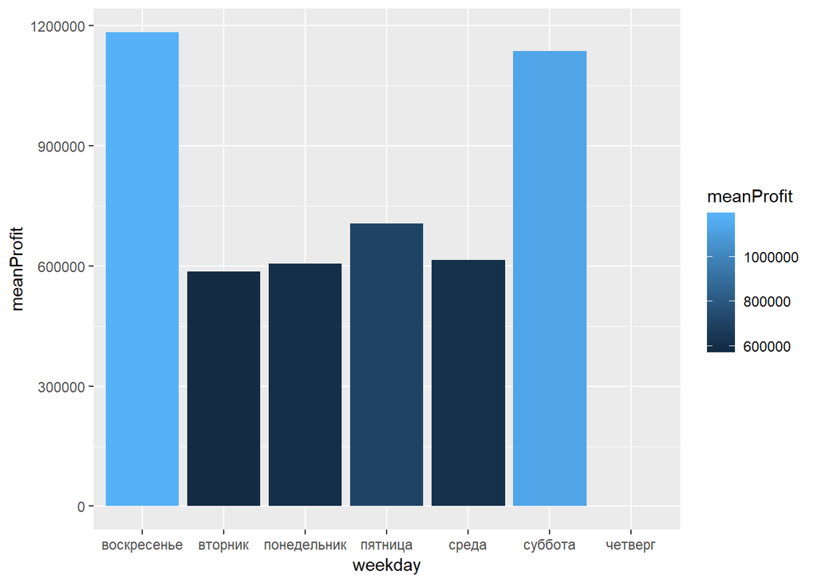

```r
df_sale_max_days<-df%>%group_by(weekday)%>%summarize(meanProfit = mean(Profit), meanCustomer=mean(Traffic))
ggplot(data=df_sale_max_days, aes(weekday, meanProfit, fill=meanProfit, binwidth = 1))+
  geom_bar(stat="identity")
```

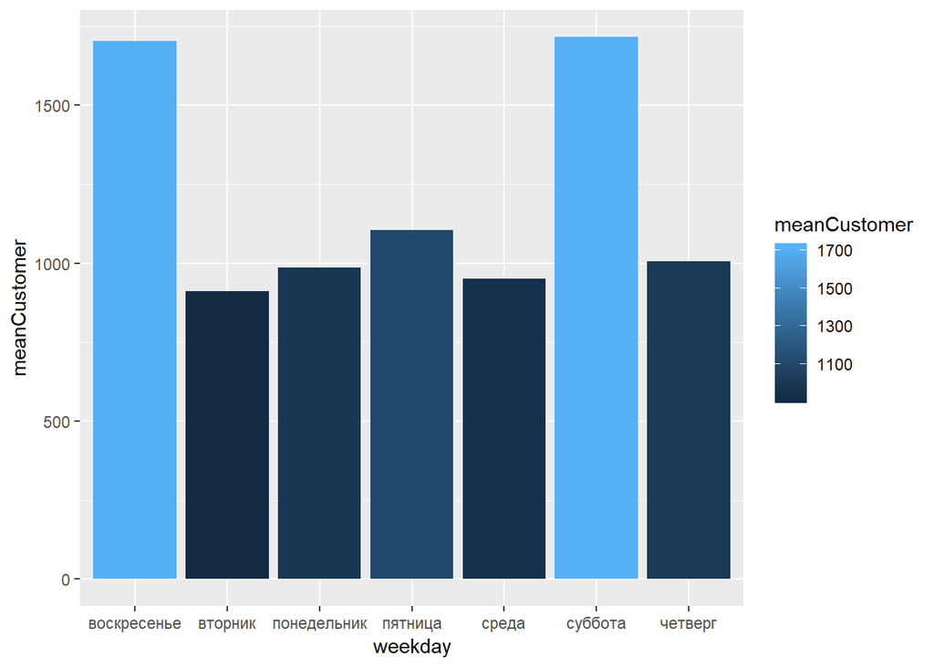

```r
ggplot(data=df_sale_max_days, aes(weekday, meanCustomer, fill=meanCustomer, binwidth = 1))+
  geom_bar(stat="identity")
```

### Sunday, Saturday and Friday have the highest mean Profit and customers.

# So, we can do a conclusion, that we should do discounts, use ads during winter,spring to get more traffic.Also, make good deal during workdays, like 20% discount only on Thursdays.

# TRAFFIC

### Now, let’s analyze does discount affect to traffic of customers or not:

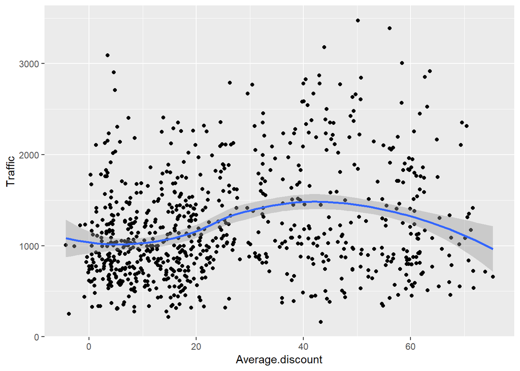

```r
df_discount<-df%>%mutate(Discount_show=ifelse(Average.discount<30,'>>30%',ifelse(Average.discount>=30&Average.discount<=50,'30%-50%', '<<50%')))
df_discount_1<-df_discount%>%group_by(Discount_show)%>%summarize(AverageTraffic= mean(Traffic), Average_customer=mean(Receipt..customers.))
ggplot(data=df, aes(Average.discount,Traffic))+
  geom_point()+
  geom_smooth()
```

###We can see that discount from 30-50% works well, we should cut discount which over 60%

### Does high traffic mean that they become customers?

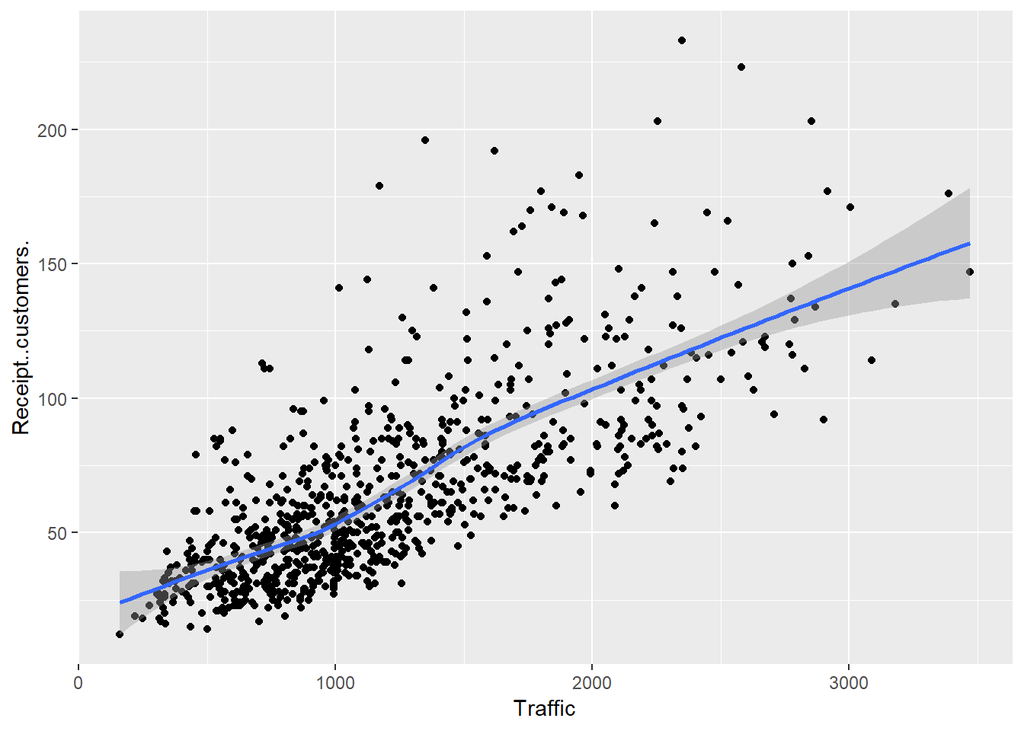

```r
ggplot(data=df, aes(Traffic, Receipt..customers.))+
  geom_point()+
  geom_smooth(model=lm)
```

### Yes, more traffic, more clients.

# We should make discount range from 30-50%. Also, should work with ads.

# DISCOUNT

## 6. How discount changes through month and weekday?

```r
df_disc_month<-df%>%group_by(month)%>%summarize(meanDiscount=mean(Average.discount), meanProfit= mean(Profit))
datatable(df_disc_month)
```

|  | month | meanDiscount | meanProfit |
| --- | --- | --- | --- |
| 1 | 1 | 46.1623913043478 | 570194.52173913 |
| 2 | 2 | 57.9622093023256 | 392701.837209302 |
| 3 | 3 | 14.7488172043011 | 688453.956989247 |
| 4 | 4 | 10.9108860759494 |  |
| 5 | 5 | 13.0616129032258 | 820477.5 |
| 6 | 6 | 18.7378333333333 | 878132.316666667 |
| 7 | 7 | 40.1440322580645 | 794000.370967742 |
| 8 | 8 | 48.0241935483871 | 896031.161290323 |
| 9 | 9 | 8.80716666666667 | 964915.6 |
| 10 | 10 | 5.55935483870968 | 1176002.87096774 |

[output cut: 2 more lines]

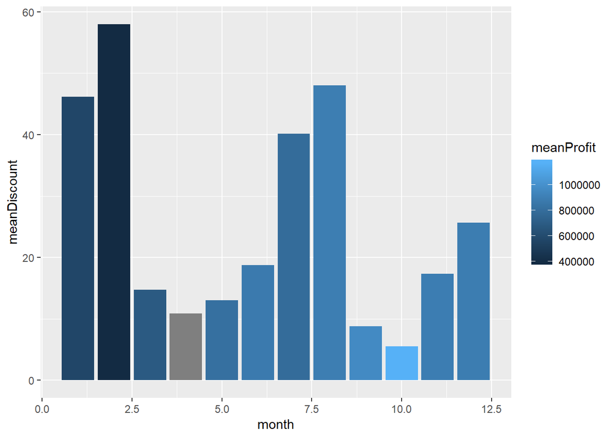

```r
ggplot(data=df_disc_month, aes(month, meanDiscount, fill=meanProfit))+
  geom_bar(stat='identity')
```

```r
df_disc_weekday<-df%>%group_by(weekday)%>%summarize(meanDiscount=mean(Average.discount), meanProfit= mean(Profit))
datatable(df_disc_weekday)
```

|  | weekday | meanDiscount | meanProfit |
| --- | --- | --- | --- |
| 1 | воскресенье | 26.9222413793103 | 1183475.47413793 |
| 2 | вторник | 25.148347826087 | 585421.652173913 |
| 3 | понедельник | 25.91 | 605915.92173913 |
| 4 | пятница | 25.9090517241379 | 706236.905172414 |
| 5 | среда | 24.699652173913 | 615540.826086957 |
| 6 | суббота | 27.4378448275862 | 1136947.53448276 |
| 7 | четверг | 24.6480172413793 |  |

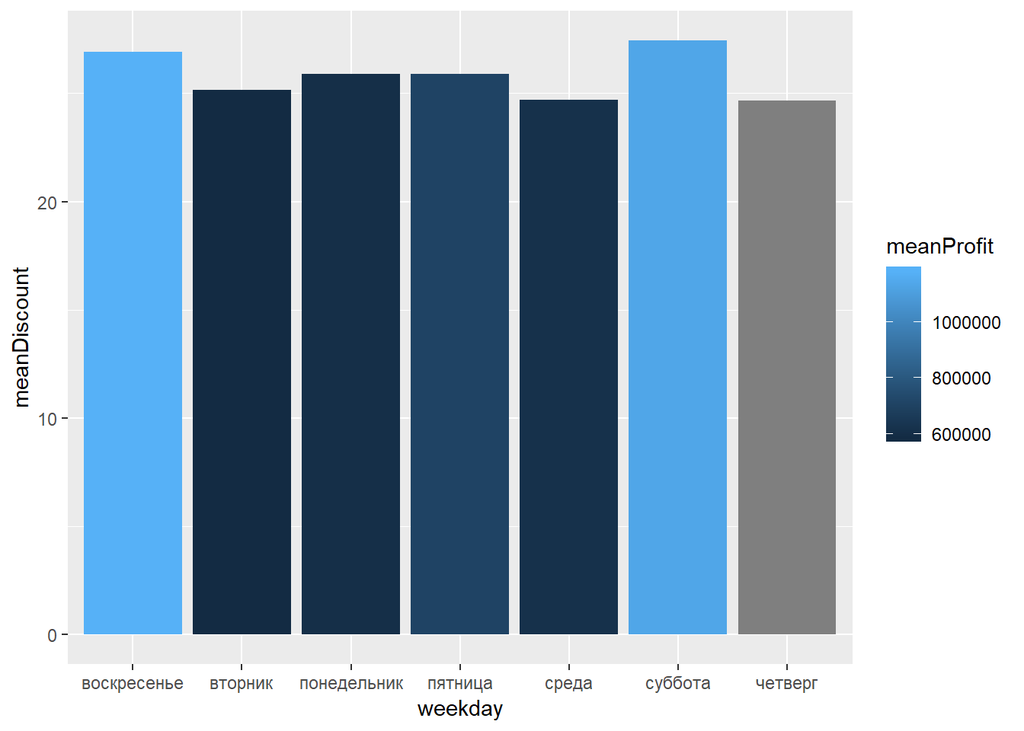

```r
ggplot(data=df_disc_weekday, aes(weekday, meanDiscount, fill=meanProfit))+
  geom_bar(stat='identity')
```

## As a result, we can make a concclusion that the highest profit was in October, but it has the lowest discount average and ,medium amount of customers

## How discount affects to the profit of company

```r
summary(df$Diff..KZT)
```

```
##     Min.  1st Qu.   Median     Mean  3rd Qu.     Max.
## -1827908  -506962  -225690  -202305    80360  1927760
```

```r
summary(df$Average.discount)
```

```
##    Min. 1st Qu.  Median    Mean 3rd Qu.    Max.
##   -4.38    8.45   19.03   25.81   41.88   75.33
```

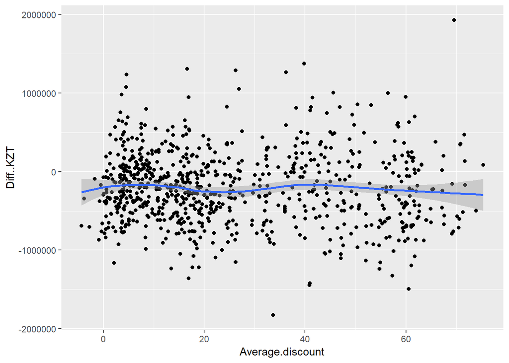

```r
ggplot(data= df, aes(Average.discount, Diff..KZT))+
  geom_point()+
  geom_smooth(method='loess')
```

###Basicly, we see that, discount doesn’t affect to the Difference.Therefore, cutting discount doesn’twork

## Let’s now check does having a high discount, leds to a big differeniation?

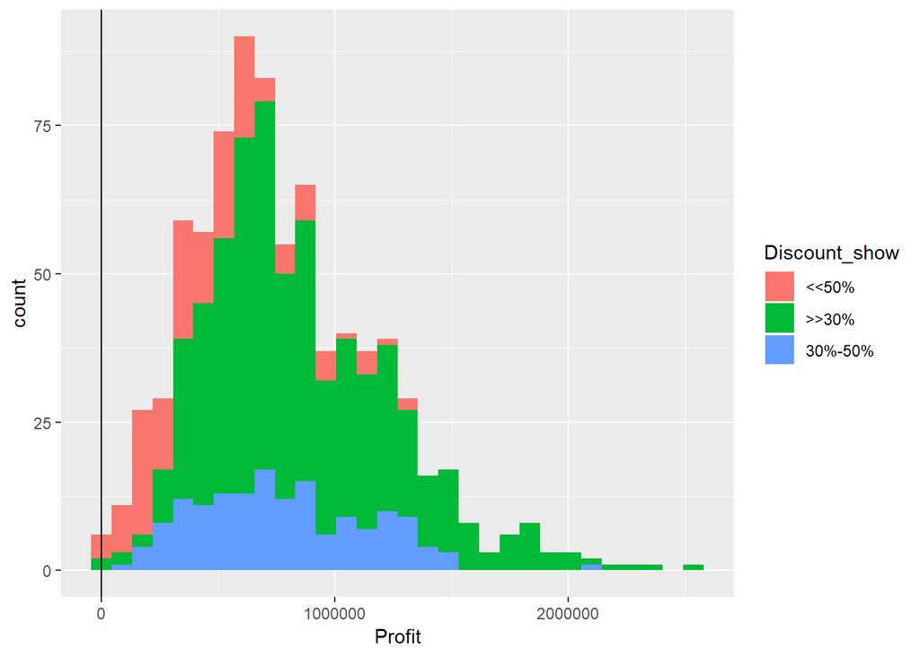

```r
options(scipen=100000)
ggplot(data=df_discount, aes(Profit, fill= Discount_show))+
  geom_histogram()+
  geom_vline(xintercept = 3)
```

### Discount didn’t cost any changes, but itss good source to make high traffic

# AVERAGE PIECE PRICE

## How Average price piece with Difference + выбросы

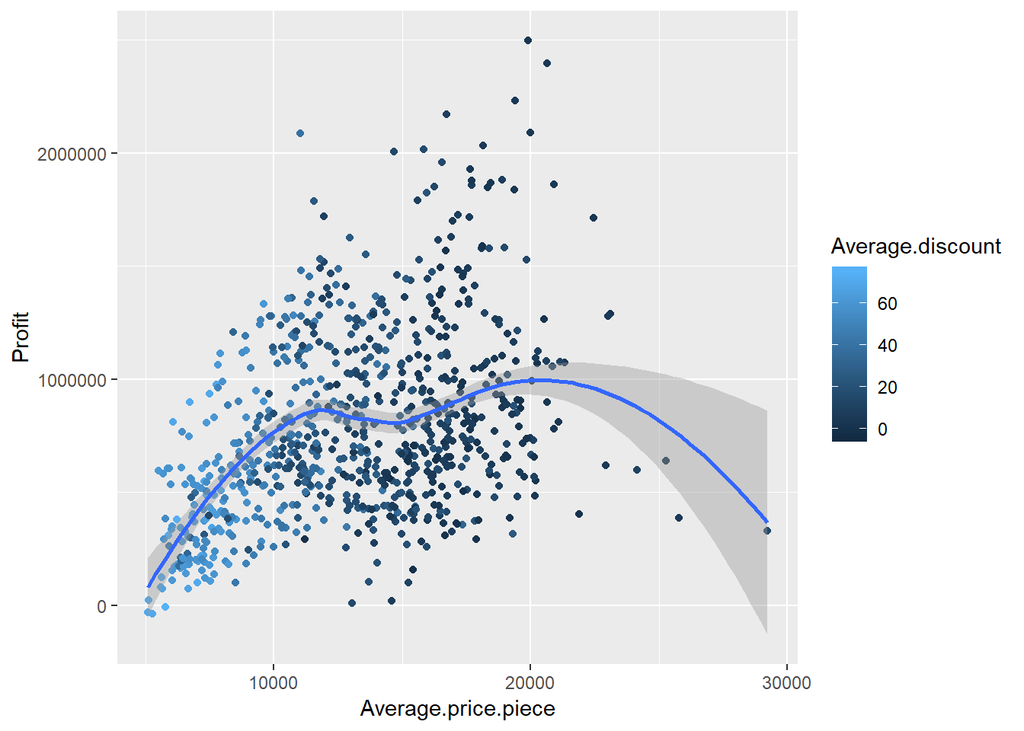

```r
ggplot(data=df%>%filter(Average.price.piece<40000),aes(Average.price.piece, Profit, color = Average.discount))+
  geom_point()+
   geom_smooth(method='loess')
```

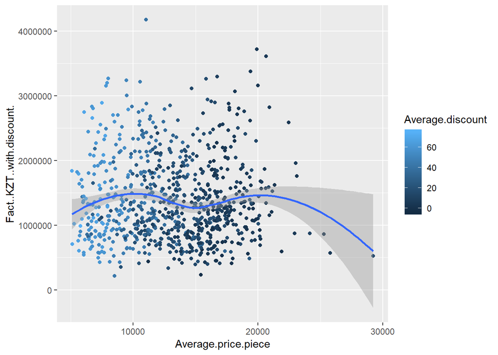

```r
ggplot(data=df%>%filter(Average.price.piece<40000),aes(Average.price.piece, Fact..KZT..with.discount., color = Average.discount))+
  geom_point()+
   geom_smooth(method='loess')
```

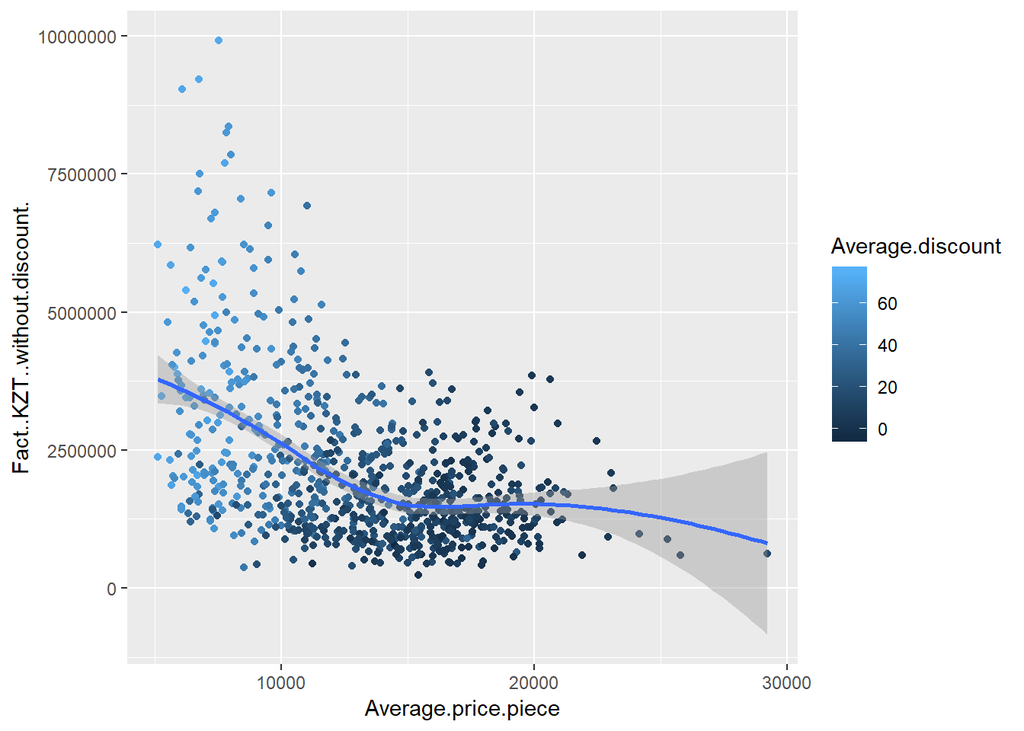

```r
ggplot(data=df%>%filter(Average.price.piece<40000),aes(Average.price.piece, Fact..KZT..without.discount., color = Average.discount))+
  geom_point()+
   geom_smooth(method='loess')
```

##So we can made a conclusion that the profit increase, when Average piece price 0-10000, 15000-20000, profit increases.Therefore we should do discount to expensive items.

# PRODUCTIVITY

## How work worktime, productivity changes through a month? Does it affect to profit?

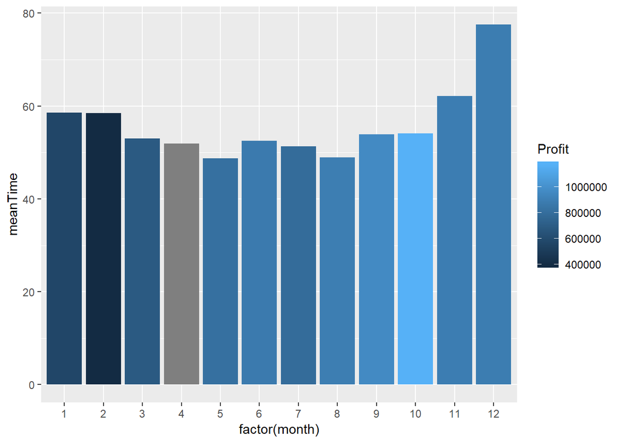

```r
df_day_month<-df%>%group_by(month)%>%summarize(meanTime=mean(Qty.of.hours),Profit=mean(Profit))
ggplot(data=df_day_month, aes(factor(month), meanTime, fill=Profit))+
  geom_bar(stat='identity')
```

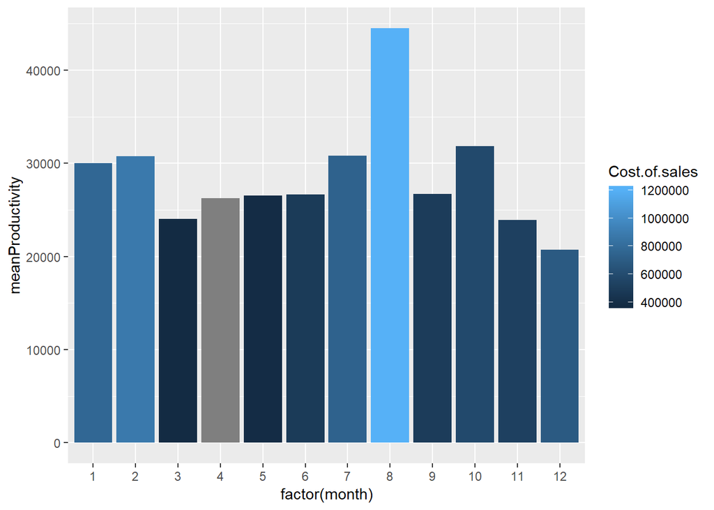

```r
df_day_month<-df%>%group_by(month)%>%summarize(meanProductivity=mean(Productivity),Cost.of.sales=mean(Cost.of.sales))
ggplot(data=df_day_month, aes(factor(month), meanProductivity, fill=Cost.of.sales))+
  geom_bar(stat='identity')
```